# Take Home #2

## Pavel Muñoz y Javier Silva

### 24/06/2022

# Introducción

En esta tarea se analiza la evolución del COVID-19 en Chile el año 2022. Esta data proviene del Ministerio de Ciencia, Tecnología, Conocimiento e Innovación, la cual contiene los PCR tomados por día, como también los casos positivos registrados y la positividad de cada día. Analizaremos el rebrote que se ha estado dando desde mayo, creando un modelo con PyMC.

En primer lugar importamos las librerías necesarias para ejecutar el modelo. Luego extraemos la data que necesitamos con el formato correcto para poder hacer el análisis.

```python
import pymc3 as pm
import arviz as az
import seaborn as sns
import pandas as pd
import matplotlib
import matplotlib.pyplot as plt
from IPython.display import display, Markdown

sampler_kwargs = {'chains': 4, 'cores': 4, 'return_inferencedata': True}
```

```
WARNING (theano.tensor.blas): Using NumPy C-API based implementation for BLAS functions.
```

```python
meandpos = pd.read_csv('https://raw.githubusercontent.com/MinCiencia/Datos-COVID19/master/output/producto49/Positividad_Diaria_Media_T.csv')
meandpos['Fecha'] = pd.to_datetime(meandpos['Fecha'], format = '%Y-%m-%d')
meandpos = meandpos[meandpos['Fecha']>'2022-01']
meandpos['pcr'] = meandpos['pcr'].astype(int)
meandpos['casos pcr'] = meandpos['casos pcr'].astype(int)
meandpos['casos ag'] = meandpos['casos ag'].astype(int)
```

```python
meandpos
```

|  | Fecha | pcr | casos pcr | casos ag | positividad pcr | mediamovil_positividad_pcr |
| --- | --- | --- | --- | --- | --- | --- |
| 648 | 2022-01-02 | 54709 | 1723 | 198 | 0.0315 | 0.0270 |
| 649 | 2022-01-03 | 23586 | 870 | 135 | 0.0369 | 0.0286 |
| 650 | 2022-01-04 | 21305 | 810 | 248 | 0.0380 | 0.0300 |
| 651 | 2022-01-05 | 43127 | 1380 | 478 | 0.0320 | 0.0314 |
| 652 | 2022-01-06 | 64928 | 2493 | 641 | 0.0384 | 0.0334 |
| ... | ... | ... | ... | ... | ... | ... |
| 817 | 2022-06-20 | 38531 | 5151 | 1998 | 0.1337 | 0.1371 |
| 818 | 2022-06-21 | 16554 | 2472 | 1854 | 0.1493 | 0.1406 |
| 819 | 2022-06-22 | 32588 | 4790 | 3969 | 0.1470 | 0.1417 |
| 820 | 2022-06-23 | 36599 | 5428 | 2610 | 0.1483 | 0.1428 |
| 821 | 2022-06-24 | 34811 | 6017 | 4817 | 0.1728 | 0.1468 |

174 rows × 6 columns

Para analizar de mejor manera la data, vamos a graficar las variables contenidas y de esa manera decidir qué variable usaremos para construir el modelo.

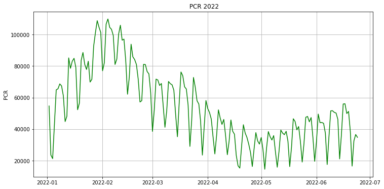

```python
fig, ax = plt.subplots(figsize = (12,6))
meses = meandpos['Fecha']
pcr = meandpos['pcr']
ax.plot(meses,pcr,c="green")
ax.set(ylabel= 'PCR', title = ' PCR 2022')
plt.grid()
```

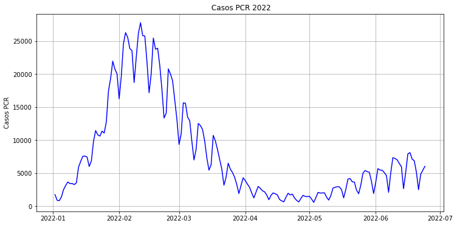

```python
fig, ax = plt.subplots(figsize = (12,6))
meses = meandpos['Fecha']
cpcr = meandpos['casos pcr']
ax.plot(meses,cpcr,c="blue")
ax.set(ylabel= 'Casos PCR', title = ' Casos PCR 2022')
plt.grid()
```

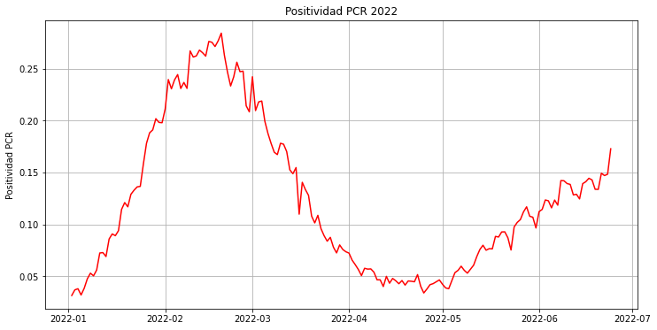

```python
fig, ax = plt.subplots(figsize = (12,6))
meses = meandpos['Fecha']
tasa = meandpos['positividad pcr']
ax.plot(meses,tasa,c="red")
ax.set(ylabel= 'Positividad PCR', title = 'Positividad PCR 2022')
plt.grid()
```

Solo analizaremos el rebrote que se genera aproximadamente al inicio de Mayo de 2022 hasta el día de hoy. La variable que mejor representa este crecimiento es la positividad, por lo cual usaremos esta para crear nuestro modelo.

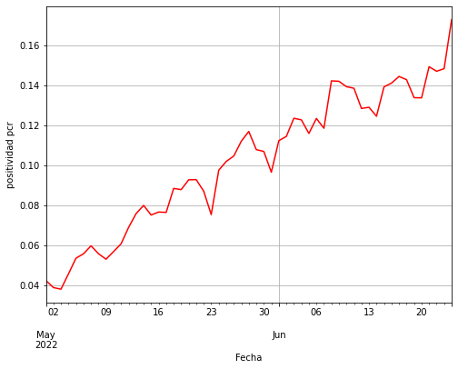

```python
mayo_junio = meandpos[meandpos['Fecha']>'2022-04-30']
ax = mayo_junio.iloc[:].plot('Fecha', 'positividad pcr', legend=False, figsize=(8,6),c="red")
ax.set_ylabel('positividad pcr')
plt.grid()
```

```python
t = (mayo_junio['Fecha'] - mayo_junio['Fecha'].iat[0]).dt.days.values
tasa = mayo_junio['positividad pcr'].values
df = pd.DataFrame({'Fecha': t, 'Positividad': tasa})
df.head()
```

|  | Fecha | Positividad |
| --- | --- | --- |
| 0 | 0 | 0.0423 |
| 1 | 1 | 0.0388 |
| 2 | 2 | 0.0380 |
| 3 | 3 | 0.0457 |
| 4 | 4 | 0.0535 |

## Modelo

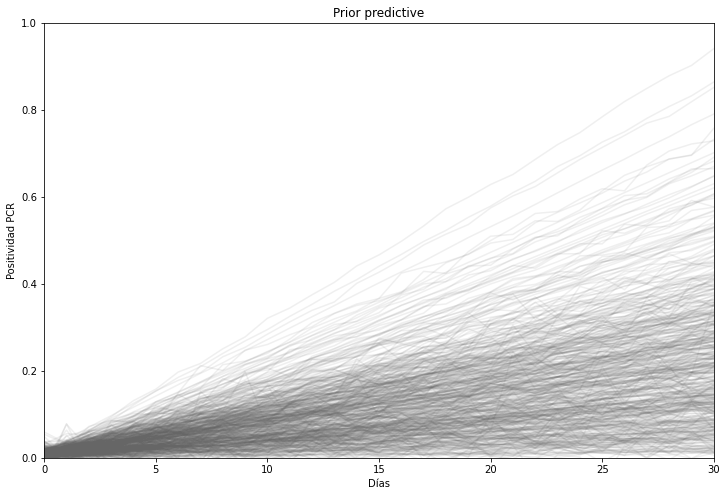

```python
with pm.Model(check_bounds = False) as modelo1:
    a = pm.HalfNormal('a', 0.01)
    b = pm.HalfNormal('b', 0.01)
    eps = pm.HalfNormal('eps', 0.01)
    trend = pm.Deterministic('trend', a + b*t)

    pm.Normal('obs',
              mu = trend,
              sigma = eps,
              observed = tasa)

    prior_pred = pm.sample_prior_predictive()


fig, ax = plt.subplots(figsize=(12,8))
ax.plot(prior_pred["obs"].T,color=".4",alpha=.1)
ax.set(ylim=(0,1),
       xlim=(0,30),
       title = "Prior predictive",
       xlabel="Días",
       ylabel="Positividad PCR");
```

A partir del modelo generado, lo ajustamos y analizamos los resultados con arviz.

```python
with modelo1:
    trace_modelo1 = pm.sample (**sampler_kwargs, tune=2500)
```

```
Auto-assigning NUTS sampler...
Initializing NUTS using jitter+adapt_diag...
Multiprocess sampling (4 chains in 4 jobs)
NUTS: [eps, b, a]
```

100.00% [14000/14000 00:05<00:00 Sampling 4 chains, 0 divergences]

```
Sampling 4 chains for 2_500 tune and 1_000 draw iterations (10_000 + 4_000 draws total) took 19 seconds.
```

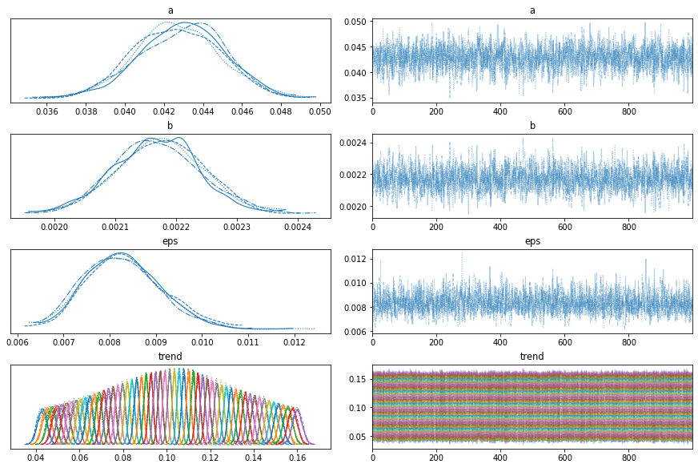

```python
az.plot_trace(trace_modelo1);
```

```python
az.summary(trace_modelo1)
```

|  | mean | sd | hdi_3% | hdi_97% | mcse_mean | mcse_sd | ess_bulk | ess_tail | r_hat |
| --- | --- | --- | --- | --- | --- | --- | --- | --- | --- |
| a | 0.043 | 0.002 | 0.039 | 0.047 | 0.0 | 0.0 | 1639.0 | 1782.0 | 1.0 |
| b | 0.002 | 0.000 | 0.002 | 0.002 | 0.0 | 0.0 | 1600.0 | 1612.0 | 1.0 |
| eps | 0.008 | 0.001 | 0.007 | 0.010 | 0.0 | 0.0 | 1542.0 | 1165.0 | 1.0 |
| trend[0] | 0.043 | 0.002 | 0.039 | 0.047 | 0.0 | 0.0 | 1639.0 | 1782.0 | 1.0 |
| trend[1] | 0.045 | 0.002 | 0.041 | 0.049 | 0.0 | 0.0 | 1649.0 | 1781.0 | 1.0 |
| trend[2] | 0.047 | 0.002 | 0.043 | 0.051 | 0.0 | 0.0 | 1660.0 | 1891.0 | 1.0 |
| trend[3] | 0.049 | 0.002 | 0.046 | 0.053 | 0.0 | 0.0 | 1674.0 | 1979.0 | 1.0 |
| trend[4] | 0.051 | 0.002 | 0.048 | 0.055 | 0.0 | 0.0 | 1689.0 | 2010.0 | 1.0 |
| trend[5] | 0.054 | 0.002 | 0.050 | 0.057 | 0.0 | 0.0 | 1707.0 | 2021.0 | 1.0 |
| trend[6] | 0.056 | 0.002 | 0.052 | 0.059 | 0.0 | 0.0 | 1727.0 | 2046.0 | 1.0 |
| trend[7] | 0.058 | 0.002 | 0.055 | 0.062 | 0.0 | 0.0 | 1746.0 | 2068.0 | 1.0 |
| trend[8] | 0.060 | 0.002 | 0.057 | 0.063 | 0.0 | 0.0 | 1772.0 | 2126.0 | 1.0 |
| trend[9] | 0.062 | 0.002 | 0.059 | 0.066 | 0.0 | 0.0 | 1801.0 | 2150.0 | 1.0 |
| trend[10] | 0.065 | 0.002 | 0.062 | 0.068 | 0.0 | 0.0 | 1832.0 | 2307.0 | 1.0 |
| trend[11] | 0.067 | 0.002 | 0.064 | 0.070 | 0.0 | 0.0 | 1871.0 | 2280.0 | 1.0 |
| trend[12] | 0.069 | 0.002 | 0.066 | 0.072 | 0.0 | 0.0 | 1913.0 | 2349.0 | 1.0 |
| trend[13] | 0.071 | 0.001 | 0.068 | 0.074 | 0.0 | 0.0 | 1962.0 | 2391.0 | 1.0 |
| trend[14] | 0.073 | 0.001 | 0.070 | 0.076 | 0.0 | 0.0 | 2018.0 | 2439.0 | 1.0 |
| trend[15] | 0.075 | 0.001 | 0.073 | 0.078 | 0.0 | 0.0 | 2080.0 | 2499.0 | 1.0 |
| trend[16] | 0.078 | 0.001 | 0.075 | 0.080 | 0.0 | 0.0 | 2153.0 | 2516.0 | 1.0 |
| trend[17] | 0.080 | 0.001 | 0.077 | 0.082 | 0.0 | 0.0 | 2238.0 | 2594.0 | 1.0 |
| trend[18] | 0.082 | 0.001 | 0.080 | 0.084 | 0.0 | 0.0 | 2336.0 | 2704.0 | 1.0 |
| trend[19] | 0.084 | 0.001 | 0.082 | 0.086 | 0.0 | 0.0 | 2443.0 | 2656.0 | 1.0 |
| trend[20] | 0.086 | 0.001 | 0.084 | 0.089 | 0.0 | 0.0 | 2565.0 | 2764.0 | 1.0 |
| trend[21] | 0.088 | 0.001 | 0.086 | 0.091 | 0.0 | 0.0 | 2706.0 | 2722.0 | 1.0 |
| trend[22] | 0.091 | 0.001 | 0.089 | 0.093 | 0.0 | 0.0 | 2868.0 | 2627.0 | 1.0 |
| trend[23] | 0.093 | 0.001 | 0.091 | 0.095 | 0.0 | 0.0 | 3032.0 | 2663.0 | 1.0 |
| trend[24] | 0.095 | 0.001 | 0.093 | 0.097 | 0.0 | 0.0 | 3192.0 | 2799.0 | 1.0 |
| trend[25] | 0.097 | 0.001 | 0.095 | 0.099 | 0.0 | 0.0 | 3349.0 | 2818.0 | 1.0 |
| trend[26] | 0.099 | 0.001 | 0.097 | 0.102 | 0.0 | 0.0 | 3501.0 | 2676.0 | 1.0 |
| trend[27] | 0.101 | 0.001 | 0.099 | 0.104 | 0.0 | 0.0 | 3631.0 | 2838.0 | 1.0 |
| trend[28] | 0.104 | 0.001 | 0.101 | 0.106 | 0.0 | 0.0 | 3733.0 | 3040.0 | 1.0 |
| trend[29] | 0.106 | 0.001 | 0.104 | 0.108 | 0.0 | 0.0 | 3790.0 | 2962.0 | 1.0 |
| trend[30] | 0.108 | 0.001 | 0.106 | 0.110 | 0.0 | 0.0 | 3796.0 | 3057.0 | 1.0 |
| trend[31] | 0.110 | 0.001 | 0.108 | 0.112 | 0.0 | 0.0 | 3768.0 | 3033.0 | 1.0 |
| trend[32] | 0.112 | 0.001 | 0.110 | 0.115 | 0.0 | 0.0 | 3708.0 | 3077.0 | 1.0 |
| trend[33] | 0.114 | 0.001 | 0.112 | 0.117 | 0.0 | 0.0 | 3627.0 | 3028.0 | 1.0 |
| trend[34] | 0.117 | 0.001 | 0.114 | 0.119 | 0.0 | 0.0 | 3533.0 | 3028.0 | 1.0 |
| trend[35] | 0.119 | 0.001 | 0.117 | 0.121 | 0.0 | 0.0 | 3428.0 | 2983.0 | 1.0 |
| trend[36] | 0.121 | 0.001 | 0.119 | 0.123 | 0.0 | 0.0 | 3319.0 | 3050.0 | 1.0 |
| trend[37] | 0.123 | 0.001 | 0.121 | 0.126 | 0.0 | 0.0 | 3197.0 | 3152.0 | 1.0 |
| trend[38] | 0.125 | 0.001 | 0.123 | 0.128 | 0.0 | 0.0 | 3087.0 | 3061.0 | 1.0 |
| trend[39] | 0.127 | 0.001 | 0.125 | 0.130 | 0.0 | 0.0 | 2977.0 | 3024.0 | 1.0 |
| trend[40] | 0.130 | 0.001 | 0.127 | 0.132 | 0.0 | 0.0 | 2880.0 | 2930.0 | 1.0 |
| trend[41] | 0.132 | 0.002 | 0.129 | 0.135 | 0.0 | 0.0 | 2783.0 | 2864.0 | 1.0 |
| trend[42] | 0.134 | 0.002 | 0.131 | 0.137 | 0.0 | 0.0 | 2698.0 | 2867.0 | 1.0 |
| trend[43] | 0.136 | 0.002 | 0.133 | 0.139 | 0.0 | 0.0 | 2620.0 | 2867.0 | 1.0 |
| trend[44] | 0.138 | 0.002 | 0.135 | 0.142 | 0.0 | 0.0 | 2553.0 | 2825.0 | 1.0 |
| trend[45] | 0.141 | 0.002 | 0.137 | 0.144 | 0.0 | 0.0 | 2488.0 | 2826.0 | 1.0 |
| trend[46] | 0.143 | 0.002 | 0.140 | 0.146 | 0.0 | 0.0 | 2430.0 | 2886.0 | 1.0 |
| trend[47] | 0.145 | 0.002 | 0.142 | 0.148 | 0.0 | 0.0 | 2379.0 | 2864.0 | 1.0 |
| trend[48] | 0.147 | 0.002 | 0.144 | 0.151 | 0.0 | 0.0 | 2330.0 | 2885.0 | 1.0 |
| trend[49] | 0.149 | 0.002 | 0.146 | 0.153 | 0.0 | 0.0 | 2287.0 | 2803.0 | 1.0 |
| trend[50] | 0.151 | 0.002 | 0.148 | 0.155 | 0.0 | 0.0 | 2250.0 | 2825.0 | 1.0 |
| trend[51] | 0.154 | 0.002 | 0.150 | 0.157 | 0.0 | 0.0 | 2213.0 | 2878.0 | 1.0 |
| trend[52] | 0.156 | 0.002 | 0.152 | 0.160 | 0.0 | 0.0 | 2181.0 | 2837.0 | 1.0 |
| trend[53] | 0.158 | 0.002 | 0.154 | 0.162 | 0.0 | 0.0 | 2150.0 | 2695.0 | 1.0 |
| trend[54] | 0.160 | 0.002 | 0.156 | 0.165 | 0.0 | 0.0 | 2123.0 | 2676.0 | 1.0 |

El modelo no presenta fallos y tiene buen comportamiento, lo cual se puede ver con los gráficos de arviz y el summary, donde se aprecia que el modelo converge.

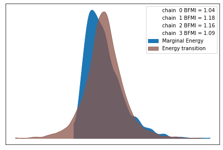

```python
az.plot_energy(trace_modelo1);
```

Este gráfico de energía muestra básicamente que las áreas coinciden en gran parte, por lo cual la conclusión es similar a la de los otros gráficos de arviz, es decir, el modelo converge. Si bien ambos gráficos explican lo mismo, este último funciona mejor con bases de datos más grandes, por lo cual, es suficiente solo basar el análisis en los primeros gráficos.